# Coursera Data Science Specialization Natural Language Processing Project

YJ K  
08/16/2015

### Background

This Coursera Data Science Specilization Capstone Project is to build a data product to predict the next word during typing. It takes the text data from Twitter, blogs and news (HC Corpora www.corpora.heliohost.org) as training corpora and the prediction is made based on model built on the n-grams extracted from these corpora. This project involves the following important components:

- N-gram model building
- Prediction model building
- Data product development

### N-gram Model

The n-gram prediction model can be expressed as follow:

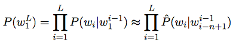

Here the prediction of next word is based on the Markov assumption, i.e. the probability of the i-th word is only related to the most recent n-1 tokens. Due to the restriction of hardware resources, the corpora are only tokenized up to fourgrams. Details of tokenization procedure can be found in the milestone report:

http://rpubs.com/kuantumk/NLP_milestone

### Backoff Prediction Model

In the final predition data product, the “Stupid Backoff” model is used to predict the next word. Concretely, the model can be expressed as follow:

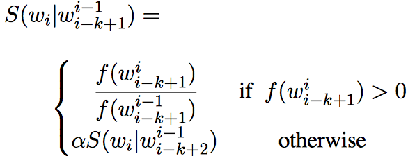

When a string is typed in, the last three words are grabed and the fourgram data table is searched. The word with highest probability is returned. If not, we grab the last two words of the input string and search the trigram data table, and so forth.

### Shiny App

- The Shiny App has a minimalism design with only an input text box and an output text box.
- The prediction is reactive, i.e., the prediction automatically shows on the right hand side as you type.
- “Stupid Backoff” model is simply returning the word with highest probability, it may not predict everything you need.
- Therefore, the most probable top 3 words are offered instead to provide perplexity.
- You can really write a sentence that makes some sense by choosing the predicted words :)
- Enjoy: http://kuantumk.shinyapps.io/Capstone